# 同赛事与对手强度λ接入FM17及alpha：三期固定策略对照

本研究按用户要求，将既有同赛事样本和对手强度归一化接入FM-1.7.0及FM-1.8.0-alpha.1原生λ阶段。正式模型不替换，规则不根据已知赛果调整。三期26098、26101、26102属于已知结果历史诊断，不是独立样本外或前瞻验证。

## 输入、契约与流程

冻结父FM17及alpha、历史比分/赛事元数据、独立目标及未来期名单、固定运行策略，均由客户端核验哈希。一个fixture/cutoff对应一套预测；比分网格每行是一个主客进球组合，净胜球为主减客；W/D/L是实际北单让胜/让平/让负。UTC决策截止为逐场T−24h，日粒度历史可用时间date+1 UTC仅为诊断代理。精确目标及未来比赛身份排除，实际标签严格晚于冻结与独立重放才在评分程序打开；本会话先前已看过部分结果，不能称盲测。

流程：同赛事筛选 → 全队网络、共享截止准入及近期0.5混合 → 同支持raw或攻防Poisson ridge 0.05 → 原生DC（ρ固定−0.1）→ **继承原置信审查及原生/市场选择** → FM17累计90%核心/外围0.3，或alpha无尾压缩/前三档让平校正 → 实际北单让球映射。固定参数未拟合本批标签。94个此前冻结的同cutoff拟合按原输入、策略、源/实现身份和独立重放收据复用；23个同cutoff稀疏支持裁决同样保留。不会跨截止、源或实现复用模型；法国U21样例另行估计。原生估计失败明确列入覆盖台账，仍保留原冻结模型；不得把未估计说成已整合。市场来源的完整流程保留市场网格，无需重复估计不生效的λ；法国U21按预先指定样例另给出新原生λ供诊断，不能把市场网格称为新基本面。

四个候选：FM17+SAME_SUPPORT_RAW、ALPHA+SAME_SUPPORT_RAW隔离同赛事取样；FM17+OPPONENT_NATIVE、ALPHA+OPPONENT_NATIVE再加入对手归一化。两种原生λ使用完全相同的同赛事支持集，保留原生近期权重；glmnet采用固定ridge和网络连通性检查，不增加新依赖。FitOpponentGoals、prepare_opponent_goals和共享temporal_learning为唯一实现。新增研究客户端只编排既有函数，无包实现变化。

```r
suppressPackageStartupMessages(library(tidyverse))
root <- normalizePath(params$repository_root,mustWork=TRUE)
out <- file.path(root,params$output_dir)
manifest <- jsonlite::fromJSON(file.path(out,"manifest.json"))
replay <- jsonlite::fromJSON(file.path(out,"replay.json"))
stopifnot(replay$status=="FULL_IDENTICAL_REPLAY",replay$forecasts==346L,
  replay$sha256==manifest$forecast_sha256,
  digest::digest(file=file.path(out,"forecasts.rds"),algo="sha256")==manifest$forecast_sha256)
status <- system2("/opt/R/4.6.1/bin/Rscript",shQuote(c(file.path(root,"r/fm_lambda_integration_evaluate.R"),root,out)),
  env=paste0("R_LIBS=",shQuote(paste(.libPaths(),collapse=":"))),
  stdout=file.path(out,"qmd-evaluation.log"),stderr=file.path(out,"qmd-evaluation.log"))
stopifnot(status==0L)
evaluation <- jsonlite::fromJSON(file.path(out,"evaluation.json"))
for(name in names(evaluation$output_hashes)) stopifnot(
  digest::digest(file=file.path(out,paste0(name,".csv")),algo="sha256")==evaluation$output_hashes[[name]])
x <- readRDS(file.path(out,"forecasts.rds"))
metrics <- read_csv(file.path(out,"metrics.csv"),show_col_types=FALSE)
changes <- read_csv(file.path(out,"changes.csv"),show_col_types=FALSE)
knitr::kable(x$audit |> count(issue_id,state,selected_source,changed_native),
  caption="估计覆盖与完整流程实际改变范围；市场选择不变，失败不冒充成功")
```

估计覆盖与完整流程实际改变范围；市场选择不变，失败不冒充成功

| issue_id | state | selected_source | changed_native | n |
| --- | --- | --- | --- | --- |
| 26098 | ESTIMATED | native | TRUE | 34 |
| 26098 | NOT_REQUIRED_MARKET_ROUTING | market | FALSE | 102 |
| 26098 | UNESTIMATED | native | FALSE | 9 |
| 26101 | ESTIMATED | native | TRUE | 38 |
| 26101 | NOT_REQUIRED_MARKET_ROUTING | market | FALSE | 65 |
| 26101 | UNESTIMATED | native | FALSE | 12 |
| 26102 | ESTIMATED | market | FALSE | 1 |
| 26102 | ESTIMATED | native | TRUE | 22 |
| 26102 | NOT_REQUIRED_MARKET_ROUTING | market | FALSE | 61 |
| 26102 | UNESTIMATED | native | FALSE | 2 |

```r
knitr::kable(x$audit |> filter(state!="ESTIMATED") |> count(state,reason,sort=TRUE),
  caption="所有未估计原因及数量")
```

所有未估计原因及数量

| state | reason | n |
| --- | --- | --- |
| NOT_REQUIRED_MARKET_ROUTING | Market routing frozen: new native fit cannot affect final probabilities | 228 |
| UNESTIMATED | Sparse target competition/venue support | 23 |

## 命中与概率评分

Brier为三类别平方误差和，log loss为实际类别负对数概率，均越低越好。Top2只评价覆盖，不代表串关收益。同T−24h与较晚赛前SP分别取严格共同样本；北单概率是SP倒数归一化。

```r
knitr::kable(metrics |> filter(dimension=="all"),digits=6,
  caption="完整共同样本：四个候选、两父版本、原始网格及纯北单")
```

完整共同样本：四个候选、两父版本、原始网格及纯北单

| comparison | dimension | stratum | model | n | hits1 | hits2 | top1 | top2 | top3 | rank2 | rank3 | brier | logloss |
| --- | --- | --- | --- | --- | --- | --- | --- | --- | --- | --- | --- | --- | --- |
| same_cutoff | all | ALL | ALPHA+OPPONENT_NATIVE | 214 | 62 | 153 | 0.289720 | 0.714953 | 1 | 0.425234 | 0.285047 | 0.678697 | 1.115152 |
| same_cutoff | all | ALL | ALPHA+SAME_SUPPORT_RAW | 214 | 64 | 156 | 0.299065 | 0.728972 | 1 | 0.429907 | 0.271028 | 0.677178 | 1.112275 |
| same_cutoff | all | ALL | BEIDAN_T24 | 214 | 71 | 149 | 0.331776 | 0.696262 | 1 | 0.364486 | 0.303738 | 0.780005 | 1.342765 |
| same_cutoff | all | ALL | FM-1.7.0 | 214 | 81 | 150 | 0.378505 | 0.700935 | 1 | 0.322430 | 0.299065 | 0.683462 | 1.121824 |
| same_cutoff | all | ALL | FM-1.8.0-alpha.1 | 214 | 64 | 153 | 0.299065 | 0.714953 | 1 | 0.415888 | 0.285047 | 0.680920 | 1.118920 |
| same_cutoff | all | ALL | FM17+OPPONENT_NATIVE | 214 | 84 | 149 | 0.392523 | 0.696262 | 1 | 0.303738 | 0.303738 | 0.677718 | 1.113480 |
| same_cutoff | all | ALL | FM17+SAME_SUPPORT_RAW | 214 | 89 | 151 | 0.415888 | 0.705607 | 1 | 0.289720 | 0.294393 | 0.677247 | 1.113882 |
| same_cutoff | all | ALL | FM17-source-before-tail | 214 | 80 | 143 | 0.373832 | 0.668224 | 1 | 0.294393 | 0.331776 | 0.684848 | 1.124691 |
| near_sale | all | ALL | ALPHA+OPPONENT_NATIVE | 345 | 104 | 241 | 0.301449 | 0.698551 | 1 | 0.397101 | 0.301449 | 0.687304 | 1.129657 |
| near_sale | all | ALL | ALPHA+SAME_SUPPORT_RAW | 345 | 106 | 242 | 0.307246 | 0.701449 | 1 | 0.394203 | 0.298551 | 0.683902 | 1.124439 |
| near_sale | all | ALL | BEIDAN_LATER | 345 | 130 | 244 | 0.376812 | 0.707246 | 1 | 0.330435 | 0.292754 | 0.670167 | 1.103727 |
| near_sale | all | ALL | FM-1.7.0 | 345 | 131 | 250 | 0.379710 | 0.724638 | 1 | 0.344928 | 0.275362 | 0.683364 | 1.120218 |
| near_sale | all | ALL | FM-1.8.0-alpha.1 | 345 | 106 | 239 | 0.307246 | 0.692754 | 1 | 0.385507 | 0.307246 | 0.686339 | 1.129082 |
| near_sale | all | ALL | FM17+OPPONENT_NATIVE | 345 | 135 | 250 | 0.391304 | 0.724638 | 1 | 0.333333 | 0.275362 | 0.682373 | 1.118936 |
| near_sale | all | ALL | FM17+SAME_SUPPORT_RAW | 345 | 140 | 250 | 0.405797 | 0.724638 | 1 | 0.318841 | 0.275362 | 0.679412 | 1.114894 |
| near_sale | all | ALL | FM17-source-before-tail | 345 | 129 | 244 | 0.373913 | 0.707246 | 1 | 0.333333 | 0.292754 | 0.683083 | 1.120975 |

```r
knitr::kable(metrics |> filter(dimension=="issue"),digits=6,caption="逐期结果完整列出")
```

逐期结果完整列出

| comparison | dimension | stratum | model | n | hits1 | hits2 | top1 | top2 | top3 | rank2 | rank3 | brier | logloss |
| --- | --- | --- | --- | --- | --- | --- | --- | --- | --- | --- | --- | --- | --- |
| same_cutoff | issue | 26098 | ALPHA+OPPONENT_NATIVE | 105 | 36 | 76 | 0.342857 | 0.723810 | 1 | 0.380952 | 0.276190 | 0.665392 | 1.098041 |
| same_cutoff | issue | 26098 | ALPHA+SAME_SUPPORT_RAW | 105 | 37 | 77 | 0.352381 | 0.733333 | 1 | 0.380952 | 0.266667 | 0.661876 | 1.092080 |
| same_cutoff | issue | 26098 | BEIDAN_T24 | 105 | 35 | 76 | 0.333333 | 0.723810 | 1 | 0.390476 | 0.276190 | 0.856060 | 1.532699 |
| same_cutoff | issue | 26098 | FM-1.7.0 | 105 | 42 | 75 | 0.400000 | 0.714286 | 1 | 0.314286 | 0.285714 | 0.660731 | 1.090628 |
| same_cutoff | issue | 26098 | FM-1.8.0-alpha.1 | 105 | 35 | 75 | 0.333333 | 0.714286 | 1 | 0.380952 | 0.285714 | 0.665737 | 1.097973 |
| same_cutoff | issue | 26098 | FM17+OPPONENT_NATIVE | 105 | 44 | 74 | 0.419048 | 0.704762 | 1 | 0.285714 | 0.295238 | 0.659545 | 1.089714 |
| same_cutoff | issue | 26098 | FM17+SAME_SUPPORT_RAW | 105 | 45 | 76 | 0.428571 | 0.723810 | 1 | 0.295238 | 0.276190 | 0.655849 | 1.084647 |
| same_cutoff | issue | 26098 | FM17-source-before-tail | 105 | 40 | 68 | 0.380952 | 0.647619 | 1 | 0.266667 | 0.352381 | 0.665193 | 1.098015 |
| same_cutoff | issue | 26101 | ALPHA+OPPONENT_NATIVE | 89 | 21 | 64 | 0.235955 | 0.719101 | 1 | 0.483146 | 0.280899 | 0.688076 | 1.123163 |
| same_cutoff | issue | 26101 | ALPHA+SAME_SUPPORT_RAW | 89 | 21 | 66 | 0.235955 | 0.741573 | 1 | 0.505618 | 0.258427 | 0.686842 | 1.119716 |
| same_cutoff | issue | 26101 | BEIDAN_T24 | 89 | 31 | 59 | 0.348315 | 0.662921 | 1 | 0.314607 | 0.337079 | 0.689109 | 1.132464 |
| same_cutoff | issue | 26101 | FM-1.7.0 | 89 | 32 | 62 | 0.359551 | 0.696629 | 1 | 0.337079 | 0.303371 | 0.707467 | 1.154544 |
| same_cutoff | issue | 26101 | FM-1.8.0-alpha.1 | 89 | 23 | 65 | 0.258427 | 0.730337 | 1 | 0.471910 | 0.269663 | 0.696115 | 1.137225 |
| same_cutoff | issue | 26101 | FM17+OPPONENT_NATIVE | 89 | 33 | 62 | 0.370787 | 0.696629 | 1 | 0.325843 | 0.303371 | 0.692395 | 1.131811 |
| same_cutoff | issue | 26101 | FM17+SAME_SUPPORT_RAW | 89 | 37 | 62 | 0.415730 | 0.696629 | 1 | 0.280899 | 0.303371 | 0.691934 | 1.131694 |
| same_cutoff | issue | 26101 | FM17-source-before-tail | 89 | 33 | 61 | 0.370787 | 0.685393 | 1 | 0.314607 | 0.314607 | 0.706876 | 1.154640 |
| same_cutoff | issue | 26102 | ALPHA+OPPONENT_NATIVE | 20 | 5 | 13 | 0.250000 | 0.650000 | 1 | 0.400000 | 0.350000 | 0.706820 | 1.169337 |
| same_cutoff | issue | 26102 | ALPHA+SAME_SUPPORT_RAW | 20 | 6 | 13 | 0.300000 | 0.650000 | 1 | 0.350000 | 0.350000 | 0.714511 | 1.185186 |
| same_cutoff | issue | 26102 | BEIDAN_T24 | 20 | 5 | 14 | 0.250000 | 0.700000 | 1 | 0.450000 | 0.300000 | 0.785205 | 1.281444 |
| same_cutoff | issue | 26102 | FM-1.7.0 | 20 | 7 | 13 | 0.350000 | 0.650000 | 1 | 0.300000 | 0.350000 | 0.695971 | 1.140005 |
| same_cutoff | issue | 26102 | FM-1.8.0-alpha.1 | 20 | 6 | 13 | 0.300000 | 0.650000 | 1 | 0.350000 | 0.350000 | 0.693020 | 1.147439 |
| same_cutoff | issue | 26102 | FM17+OPPONENT_NATIVE | 20 | 7 | 13 | 0.350000 | 0.650000 | 1 | 0.300000 | 0.350000 | 0.707815 | 1.156676 |
| same_cutoff | issue | 26102 | FM17+SAME_SUPPORT_RAW | 20 | 7 | 13 | 0.350000 | 0.650000 | 1 | 0.300000 | 0.350000 | 0.724237 | 1.188110 |
| same_cutoff | issue | 26102 | FM17-source-before-tail | 20 | 7 | 14 | 0.350000 | 0.700000 | 1 | 0.350000 | 0.300000 | 0.690013 | 1.131464 |
| near_sale | issue | 26098 | ALPHA+OPPONENT_NATIVE | 144 | 46 | 100 | 0.319444 | 0.694444 | 1 | 0.375000 | 0.305556 | 0.675196 | 1.115796 |
| near_sale | issue | 26098 | ALPHA+SAME_SUPPORT_RAW | 144 | 47 | 101 | 0.326389 | 0.701389 | 1 | 0.375000 | 0.298611 | 0.670745 | 1.108546 |
| near_sale | issue | 26098 | BEIDAN_LATER | 144 | 57 | 105 | 0.395833 | 0.729167 | 1 | 0.333333 | 0.270833 | 0.663117 | 1.092623 |
| near_sale | issue | 26098 | FM-1.7.0 | 144 | 56 | 102 | 0.388889 | 0.708333 | 1 | 0.319444 | 0.291667 | 0.661773 | 1.093062 |
| near_sale | issue | 26098 | FM-1.8.0-alpha.1 | 144 | 45 | 98 | 0.312500 | 0.680556 | 1 | 0.368056 | 0.319444 | 0.673788 | 1.113645 |
| near_sale | issue | 26098 | FM17+OPPONENT_NATIVE | 144 | 59 | 102 | 0.409722 | 0.708333 | 1 | 0.298611 | 0.291667 | 0.662743 | 1.094882 |
| near_sale | issue | 26098 | FM17+SAME_SUPPORT_RAW | 144 | 60 | 103 | 0.416667 | 0.715278 | 1 | 0.298611 | 0.284722 | 0.657616 | 1.087782 |
| near_sale | issue | 26098 | FM17-source-before-tail | 144 | 55 | 97 | 0.381944 | 0.673611 | 1 | 0.291667 | 0.326389 | 0.663862 | 1.096229 |
| near_sale | issue | 26101 | ALPHA+OPPONENT_NATIVE | 115 | 27 | 85 | 0.234783 | 0.739130 | 1 | 0.504348 | 0.260870 | 0.709889 | 1.152449 |
| near_sale | issue | 26101 | ALPHA+SAME_SUPPORT_RAW | 115 | 27 | 86 | 0.234783 | 0.747826 | 1 | 0.513043 | 0.252174 | 0.708790 | 1.149881 |
| near_sale | issue | 26101 | BEIDAN_LATER | 115 | 37 | 71 | 0.321739 | 0.617391 | 1 | 0.295652 | 0.382609 | 0.701872 | 1.149811 |
| near_sale | issue | 26101 | FM-1.7.0 | 115 | 42 | 83 | 0.365217 | 0.721739 | 1 | 0.356522 | 0.278261 | 0.727588 | 1.178635 |
| near_sale | issue | 26101 | FM-1.8.0-alpha.1 | 115 | 29 | 86 | 0.252174 | 0.747826 | 1 | 0.495652 | 0.252174 | 0.716515 | 1.163903 |
| near_sale | issue | 26101 | FM17+OPPONENT_NATIVE | 115 | 43 | 83 | 0.373913 | 0.721739 | 1 | 0.347826 | 0.278261 | 0.715584 | 1.160579 |
| near_sale | issue | 26101 | FM17+SAME_SUPPORT_RAW | 115 | 47 | 82 | 0.408696 | 0.713043 | 1 | 0.304348 | 0.286957 | 0.715029 | 1.160463 |
| near_sale | issue | 26101 | FM17-source-before-tail | 115 | 42 | 82 | 0.365217 | 0.713043 | 1 | 0.347826 | 0.286957 | 0.727394 | 1.182338 |
| near_sale | issue | 26102 | ALPHA+OPPONENT_NATIVE | 86 | 31 | 56 | 0.360465 | 0.651163 | 1 | 0.290698 | 0.348837 | 0.677376 | 1.122386 |
| near_sale | issue | 26102 | ALPHA+SAME_SUPPORT_RAW | 86 | 32 | 55 | 0.372093 | 0.639535 | 1 | 0.267442 | 0.360465 | 0.672650 | 1.117029 |
| near_sale | issue | 26102 | BEIDAN_LATER | 86 | 36 | 68 | 0.418605 | 0.790698 | 1 | 0.372093 | 0.209302 | 0.639575 | 1.060697 |
| near_sale | issue | 26102 | FM-1.7.0 | 86 | 33 | 65 | 0.383721 | 0.755814 | 1 | 0.372093 | 0.244186 | 0.660377 | 1.087573 |
| near_sale | issue | 26102 | FM-1.8.0-alpha.1 | 86 | 32 | 55 | 0.372093 | 0.639535 | 1 | 0.267442 | 0.360465 | 0.667003 | 1.108366 |
| near_sale | issue | 26102 | FM17+OPPONENT_NATIVE | 86 | 33 | 65 | 0.383721 | 0.755814 | 1 | 0.372093 | 0.244186 | 0.670830 | 1.103527 |
| near_sale | issue | 26102 | FM17+SAME_SUPPORT_RAW | 86 | 33 | 65 | 0.383721 | 0.755814 | 1 | 0.372093 | 0.244186 | 0.668278 | 1.099355 |
| near_sale | issue | 26102 | FM17-source-before-tail | 86 | 32 | 65 | 0.372093 | 0.755814 | 1 | 0.383721 | 0.244186 | 0.656014 | 1.080356 |

```r
knitr::kable(metrics |> filter(dimension%in%c("event_type","source","changed_native","fit_state")),digits=6,
  caption="赛事类型、原来源、实际替换和可估计性分层；不只挑改善组")
```

赛事类型、原来源、实际替换和可估计性分层；不只挑改善组

| comparison | dimension | stratum | model | n | hits1 | hits2 | top1 | top2 | top3 | rank2 | rank3 | brier | logloss |
| --- | --- | --- | --- | --- | --- | --- | --- | --- | --- | --- | --- | --- | --- |
| same_cutoff | event_type | youth | ALPHA+OPPONENT_NATIVE | 7 | 2 | 4 | 0.285714 | 0.571429 | 1 | 0.285714 | 0.428571 | 0.689855 | 1.136297 |
| same_cutoff | event_type | youth | ALPHA+SAME_SUPPORT_RAW | 7 | 2 | 4 | 0.285714 | 0.571429 | 1 | 0.285714 | 0.428571 | 0.689855 | 1.136297 |
| same_cutoff | event_type | youth | BEIDAN_T24 | 7 | 3 | 5 | 0.428571 | 0.714286 | 1 | 0.285714 | 0.285714 | 1.077015 | 1.894867 |
| same_cutoff | event_type | youth | FM-1.7.0 | 7 | 2 | 6 | 0.285714 | 0.857143 | 1 | 0.571429 | 0.142857 | 0.703580 | 1.134328 |
| same_cutoff | event_type | youth | FM-1.8.0-alpha.1 | 7 | 2 | 4 | 0.285714 | 0.571429 | 1 | 0.285714 | 0.428571 | 0.689855 | 1.136297 |
| same_cutoff | event_type | youth | FM17+OPPONENT_NATIVE | 7 | 2 | 6 | 0.285714 | 0.857143 | 1 | 0.571429 | 0.142857 | 0.703580 | 1.134328 |
| same_cutoff | event_type | youth | FM17+SAME_SUPPORT_RAW | 7 | 2 | 6 | 0.285714 | 0.857143 | 1 | 0.571429 | 0.142857 | 0.703580 | 1.134328 |
| same_cutoff | event_type | youth | FM17-source-before-tail | 7 | 2 | 6 | 0.285714 | 0.857143 | 1 | 0.571429 | 0.142857 | 0.702499 | 1.131890 |
| same_cutoff | event_type | league | ALPHA+OPPONENT_NATIVE | 165 | 46 | 117 | 0.278788 | 0.709091 | 1 | 0.430303 | 0.290909 | 0.684570 | 1.123721 |
| same_cutoff | event_type | league | ALPHA+SAME_SUPPORT_RAW | 165 | 48 | 119 | 0.290909 | 0.721212 | 1 | 0.430303 | 0.278788 | 0.683774 | 1.121971 |
| same_cutoff | event_type | league | BEIDAN_T24 | 165 | 54 | 114 | 0.327273 | 0.690909 | 1 | 0.363636 | 0.309091 | 0.748611 | 1.296537 |
| same_cutoff | event_type | league | FM-1.7.0 | 165 | 61 | 115 | 0.369697 | 0.696970 | 1 | 0.327273 | 0.303030 | 0.688564 | 1.129058 |
| same_cutoff | event_type | league | FM-1.8.0-alpha.1 | 165 | 48 | 117 | 0.290909 | 0.709091 | 1 | 0.418182 | 0.290909 | 0.687592 | 1.128953 |
| same_cutoff | event_type | league | FM17+OPPONENT_NATIVE | 165 | 64 | 115 | 0.387879 | 0.696970 | 1 | 0.309091 | 0.303030 | 0.681023 | 1.117988 |
| same_cutoff | event_type | league | FM17+SAME_SUPPORT_RAW | 165 | 67 | 116 | 0.406061 | 0.703030 | 1 | 0.296970 | 0.296970 | 0.682120 | 1.120942 |
| same_cutoff | event_type | league | FM17-source-before-tail | 165 | 62 | 112 | 0.375758 | 0.678788 | 1 | 0.303030 | 0.321212 | 0.687681 | 1.128487 |
| same_cutoff | event_type | national | ALPHA+OPPONENT_NATIVE | 40 | 14 | 31 | 0.350000 | 0.775000 | 1 | 0.425000 | 0.225000 | 0.649601 | 1.072701 |
| same_cutoff | event_type | national | ALPHA+SAME_SUPPORT_RAW | 40 | 14 | 32 | 0.350000 | 0.800000 | 1 | 0.450000 | 0.200000 | 0.644756 | 1.064527 |
| same_cutoff | event_type | national | BEIDAN_T24 | 40 | 13 | 29 | 0.325000 | 0.725000 | 1 | 0.400000 | 0.275000 | 0.858093 | 1.438723 |
| same_cutoff | event_type | national | FM-1.7.0 | 40 | 17 | 28 | 0.425000 | 0.700000 | 1 | 0.275000 | 0.300000 | 0.663692 | 1.096437 |
| same_cutoff | event_type | national | FM-1.8.0-alpha.1 | 40 | 14 | 31 | 0.350000 | 0.775000 | 1 | 0.425000 | 0.225000 | 0.649030 | 1.071277 |
| same_cutoff | event_type | national | FM17+OPPONENT_NATIVE | 40 | 17 | 27 | 0.425000 | 0.675000 | 1 | 0.250000 | 0.325000 | 0.664071 | 1.097457 |
| same_cutoff | event_type | national | FM17+SAME_SUPPORT_RAW | 40 | 19 | 28 | 0.475000 | 0.700000 | 1 | 0.225000 | 0.300000 | 0.657026 | 1.087424 |
| same_cutoff | event_type | national | FM17-source-before-tail | 40 | 15 | 24 | 0.375000 | 0.600000 | 1 | 0.225000 | 0.400000 | 0.675406 | 1.115220 |
| same_cutoff | event_type | cup | ALPHA+OPPONENT_NATIVE | 2 | 0 | 1 | 0.000000 | 0.500000 | 1 | 0.500000 | 0.500000 | 0.737085 | 1.183252 |
| same_cutoff | event_type | cup | ALPHA+SAME_SUPPORT_RAW | 2 | 0 | 1 | 0.000000 | 0.500000 | 1 | 0.500000 | 0.500000 | 0.737085 | 1.183252 |
| same_cutoff | event_type | cup | BEIDAN_T24 | 2 | 1 | 1 | 0.500000 | 0.500000 | 1 | 0.000000 | 0.500000 | 0.768682 | 1.305016 |
| same_cutoff | event_type | cup | FM-1.7.0 | 2 | 1 | 1 | 0.500000 | 0.500000 | 1 | 0.000000 | 0.500000 | 0.587503 | 0.989053 |
| same_cutoff | event_type | cup | FM-1.8.0-alpha.1 | 2 | 0 | 1 | 0.000000 | 0.500000 | 1 | 0.500000 | 0.500000 | 0.737085 | 1.183252 |
| same_cutoff | event_type | cup | FM17+OPPONENT_NATIVE | 2 | 1 | 1 | 0.500000 | 0.500000 | 1 | 0.000000 | 0.500000 | 0.587503 | 0.989053 |

[output cut: 146 more lines]

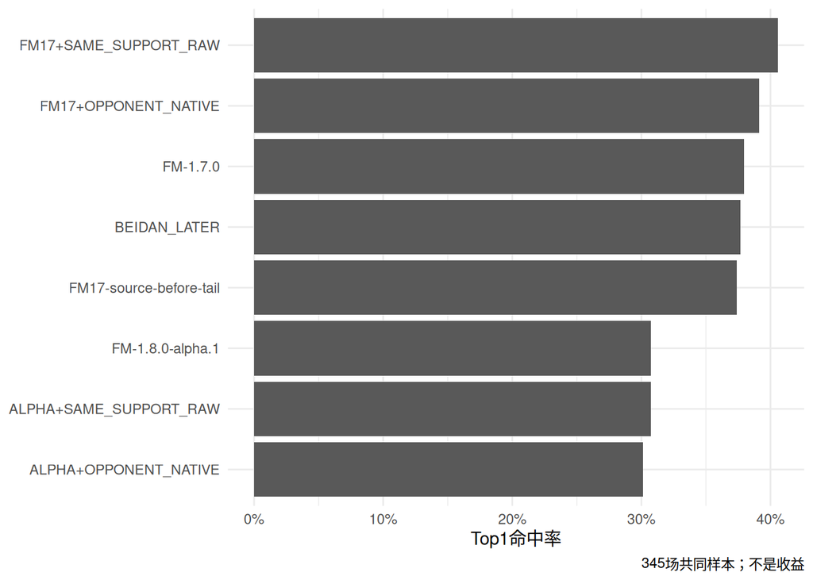

```r
metrics |> filter(dimension=="all",comparison=="near_sale") |>
  ggplot(aes(reorder(model,top1),top1)) + geom_col() + coord_flip() +
  scale_y_continuous(labels=scales::percent) + labs(x=NULL,y="Top1命中率",caption="345场共同样本；不是收益") + theme_minimal()
```

```r
knitr::kable(changes |> group_by(model) |> summarise(n=n(),changed=sum(changed_native),
  saved_top1=sum(saved_top1),lost_top1=sum(lost_top1),saved_top2=sum(saved_top2),lost_top2=sum(lost_top2),
  mean_brier_delta=mean(brier_delta),mean_logloss_delta=mean(logloss_delta),.groups="drop"),digits=6,
  caption="相对各自父版本的救回与损失；正概率评分差为退步")
```

相对各自父版本的救回与损失；正概率评分差为退步

| model | n | changed | saved_top1 | lost_top1 | saved_top2 | lost_top2 | mean_brier_delta | mean_logloss_delta |
| --- | --- | --- | --- | --- | --- | --- | --- | --- |
| ALPHA+OPPONENT_NATIVE | 345 | 94 | 3 | 5 | 9 | 7 | 0.000964 | 0.000575 |
| ALPHA+SAME_SUPPORT_RAW | 345 | 94 | 2 | 2 | 8 | 5 | -0.002438 | -0.004643 |
| FM17+OPPONENT_NATIVE | 345 | 94 | 10 | 6 | 9 | 9 | -0.000991 | -0.001282 |
| FM17+SAME_SUPPORT_RAW | 345 | 94 | 12 | 3 | 8 | 8 | -0.003952 | -0.005324 |

## 本批诊断结论

345场较晚SP共同样本中，FM17父版本131/250；同赛事raw为140/250，Brier从0.683364降到0.679412，log loss从1.120218降到1.114894；加入对手归一化为135/250、0.682373和1.118936。支持同赛事取样对本批Top1及评分有所帮助，归一化未显示额外改善。二者都仍逊于较晚北单的概率评分0.670167／1.103727，不能仅凭Top1高于北单130场就宣称概率更准确。

alpha父版本106/239；同赛事raw为106/242，归一化为104/241。raw略改善评分和Top2，归一化Brier/log loss反而略差，未修复alpha偏重让平的主要问题。T−24h的214场中FM17同赛事raw89/151、归一化84/149、父版本81/150；alpha同赛事raw64/156、归一化62/153、父版本64/153。两时点分别报告，不能把子集效果外推到全期。

以上均是固定规则的事后诊断；正式版本不因本批排名自动升级。94场替换只来自原生来源，市场来源保持父版本，缺失支持场次也保持父版本。

## 法国U21对瑞士U21

该场父版本因青年队阵容/换届、对手质量未核验而选择市场。新增λ不会自动解决阵容连续性缺口，因此保持原来源裁决；以下将原生λ变化与最终概率是否实际变化分开。

```r
id <- "26102:34"
e <- x$entries[[id]]
stage_path <- file.path(root,"results/fm16-three-issues-20261012/stage.rds")
parent_manifest <- jsonlite::fromJSON(file.path(root,"results/fm17-three-issues-20261013/manifest.json"))
stopifnot(digest::digest(file=stage_path,algo="sha256")==parent_manifest$source_hashes$parent_stage)
stage <- readRDS(stage_path)
old <- stage$native[[id]]$native$parameters
knitr::kable(old,caption="原生旧λ（此前讨论的2.17／1.39）")
```

原生旧λ（此前讨论的2.17／1.39）

| lambda_home | lambda_away |
| --- | --- |
| 2.173522 | 1.385954 |

```r
knitr::kable(x$audit |> filter(fixture_id==id),digits=6,caption="该场新λ、估计状态与实际来源")
```

该场新λ、估计状态与实际来源

| fixture_id | issue_id | home | away | league | state | reason | metadata_supported | metadata_missing | fit_origin | selected_source | changed_native | lambda_home | lambda_away | raw_same_support_home | raw_same_support_away | competition_id | fit_rows |
| --- | --- | --- | --- | --- | --- | --- | --- | --- | --- | --- | --- | --- | --- | --- | --- | --- | --- |
| 26102:34 | 26102 | 法国U21 | 瑞士U21 | 欧青U21外 | ESTIMATED | Same competition; ridge .05; frozen alpha .5 recency; no target fitting | 9968 | 0 | NEW_DIAGNOSTIC_FIT | market | FALSE | 1.98302 | 1.259914 | 2.20667 | 1.215336 | 114 | 1908 |

```r
knitr::kable(read_csv(file.path(out,"scores.csv"),show_col_types=FALSE) |> filter(fixture_id==id),digits=6,
  caption="该场各候选最终结果；市场来源保持不变是流程约束")
```

该场各候选最终结果；市场来源保持不变是流程约束

| comparison | model | fixture_id | actual_outcome | predicted_outcome | actual_rank | actual_probability | brier | logloss | top1 | top2 | top3 |
| --- | --- | --- | --- | --- | --- | --- | --- | --- | --- | --- | --- |
| near_sale | ALPHA+OPPONENT_NATIVE | 26102:34 | W | D | 3 | 0.321063 | 0.691808 | 1.136117 | FALSE | FALSE | TRUE |
| near_sale | ALPHA+SAME_SUPPORT_RAW | 26102:34 | W | D | 3 | 0.321063 | 0.691808 | 1.136117 | FALSE | FALSE | TRUE |
| near_sale | BEIDAN_LATER | 26102:34 | W | W | 1 | 0.500892 | 0.375074 | 0.691364 | TRUE | TRUE | TRUE |
| near_sale | FM-1.7.0 | 26102:34 | W | W | 1 | 0.390390 | 0.566332 | 0.940610 | TRUE | TRUE | TRUE |
| near_sale | FM-1.8.0-alpha.1 | 26102:34 | W | D | 3 | 0.321063 | 0.691808 | 1.136117 | FALSE | FALSE | TRUE |
| near_sale | FM17+OPPONENT_NATIVE | 26102:34 | W | W | 1 | 0.390390 | 0.566332 | 0.940610 | TRUE | TRUE | TRUE |
| near_sale | FM17+SAME_SUPPORT_RAW | 26102:34 | W | W | 1 | 0.390390 | 0.566332 | 0.940610 | TRUE | TRUE | TRUE |
| near_sale | FM17-source-before-tail | 26102:34 | W | L | 2 | 0.386220 | 0.579536 | 0.951349 | FALSE | TRUE | TRUE |

```r
if(!is.null(e$fit)) {
  knitr::kable(e$fit$support |> filter(team_id%in%c(e$fit$receipt$fixture$home_id,e$fit$receipt$fixture$away_id)),
    digits=5,caption="目标两队同赛事主客场支持、近期激活与ESS")
  knitr::kable(e$fit$parameters,caption="对手强度归一化新原生λ")
  knitr::kable(e$fit$same_support_raw,caption="同赛事同支持raw对照λ")
  library(beidan,lib.loc=file.path(root,"results/fm17-diagnostic-iterations-20261013/library"))
  rates <- bind_rows(old |> mutate(source="旧原生"),e$fit$same_support_raw |> mutate(source="同赛事raw"),
    e$fit$parameters |> mutate(source="同赛事+对手归一化"),
    stage$packets[[id]]$market_parameters |> select(lambda_home,lambda_away) |> mutate(source="冻结联合市场"))
  france_diagnostics <- list()
  for(i in seq_len(nrow(rates))) {
    g <- beidan:::dixon_coles_score_grid(rates$lambda_home[i],rates$lambda_away[i],-1L,1e-10,-.1)$grid |>
      as_tibble() |> mutate(margin=home_goals-away_goals)
    france_diagnostics[[i]] <- g |> summarise(win=sum(probability[margin>0]),
      win1=sum(probability[margin==1]),win2plus=sum(probability[margin>=2]),win3plus=sum(probability[margin>=3])) |>
      mutate(source=rates$source[i],.before=1)
  }
  knitr::kable(bind_rows(france_diagnostics),digits=6,caption="法国样例：新旧原生及市场DC的胜幅判断；不是最终来源切换")
}
```

法国样例：新旧原生及市场DC的胜幅判断；不是最终来源切换

| source | win | win1 | win2plus | win3plus |
| --- | --- | --- | --- | --- |
| 旧原生 | 0.545849 | 0.206892 | 0.338958 | 0.173043 |
| 同赛事raw | 0.589793 | 0.214132 | 0.375661 | 0.196527 |
| 同赛事+对手归一化 | 0.532157 | 0.214220 | 0.317937 | 0.153551 |
| 冻结联合市场 | 0.608122 | 0.221902 | 0.386220 | 0.199874 |

## 局限、复现与验收

同赛事严格取样可能使杯赛/国家队/青年队支持不足。失败保持父版本，完整期效果属于带覆盖缺口的候选叠加，不是每场λ都更新。固定原来源选择隔离λ贡献，也使市场组不会改善；不能将零变化解释为新λ无信息。未新增伤停、预计阵容、战意事实，也未验证青年队跨届球员同一性。ρ、ridge、近期权重均为固定研究参数。对手网络来自已存有限历史而非完整全联赛赛季，日期代理/90分钟口径限制继承原实验。较晚SP信息更丰富，同截止缺失使子集不代表全部；未作下注、资金或收益模拟。

完整客户端验收同时修复五份旧历史测试：FM14两份测试分别验证当前闭包可准入、过期历史闭包被拒绝及被篡改闭包被拒绝；FM17诊断逐行核对10位小数账本对应的精确策略权重、精确分量质量和ESS，并通过当前正常安装的后端执行截止变异；FM17回放在原截止和原输入上重建当前实现上下文后验证变异不变性，不改写旧封存收据；混合串场回放对照其冻结实现登记，并确认当前实现拒绝复用旧实现结果。未放宽误差阈值、删减测试或重写旧预测。原文件及SHA保存在test-repair-originals/和test-repair-recovery.json，避免覆盖既有未提交工作。所有变化位于仓库客户端测试，未修改packages/beidan/。

共享历史学习库存：prepare_opponent_goals→prepare_learning_context→AvailabilityFilter/PartitionPolicy/WeightingPolicy/verify_learning_context→FitOpponentGoals→temporal_cache_key；尾部和alpha只通过build_adjustment_evidence_context与共享验证器输出。每场收据绑定截止、排除名单、源哈希、R fit/后端传递实现、完整权重账本、ESS、固定参数及缓存键。新客户端不复制时序工具；跨cutoff不可复用。预测文件不可被非相同重放覆盖。

精确命令及结果见下方验收表和日志。复现：Rscript r/fm_lambda_integration_freeze.R ROOT；同命令追加replay；Rscript r/fm_lambda_integration_evaluate.R ROOT OUT；QUARTO_R=/opt/R/4.6.1/bin/R quarto render quarto/fm_lambda_integration_20261017.qmd –no-cache。渲染在新进程执行评分并验证输出哈希；不安装依赖、不重训预测。

```r
if(isTRUE(params$acceptance_required)) {
  acceptance <- jsonlite::fromJSON(file.path(out,"acceptance.json"),simplifyVector=FALSE)
  stopifnot(acceptance$status=="ACCEPTED",acceptance$blocking_findings==0L)
  for(file in acceptance$files) stopifnot(digest::digest(file=file.path(root,file$path),algo="sha256")==file$sha256)
  knitr::kable(bind_rows(acceptance$checks),format="html",escape=TRUE,
    caption="最终实现身份、命令、测试、审查发现及处理")
} else cat("预览，尚未最终验收。\n")
```

最终实现身份、命令、测试、审查发现及处理

| command | result |
| --- | --- |
| Rscript r/fm_lambda_integration_freeze.R ROOT; same command with replay | 346 fixtures FULL_IDENTICAL_REPLAY; 94 replaced native, 23 insufficient native, 229 unchanged market; France extra native diagnostic |
| Rscript r/fm_lambda_integration_evaluate.R ROOT OUT; independent temp-directory replay | All six CSV outputs byte-identical; same345 late and214 T24 paired cohorts; exact hashes in evaluation-replay.json |
| testthat::test_file("tests/testthat/test-fm-lambda-integration.R", load_helpers=FALSE) | 5347 passed; no failures/errors/skips; child R_LIBS explicitly inherited |
| Five repaired historical test files, normally installed beidan and explicit test-environment.json | 25 test blocks, 34813 passed assertions, no failures/errors/skips; originals preserved |
| /opt/R/4.6.1/bin/Rscript tests/testthat.R; complete explicit environment in test-environment.json | {"package": {"tests": 948, "passed": 9153, "failed": 0, "errors": 0, "warnings": 0, "skipped": 0}, "repository": {"tests": 785, "passed": 83491, "failed": 0, "errors": 0, "warnings": 0, "skipped": 2}} |
| PYTHONPATH=packages/beidan/inst/python:$PWD .venv/bin/python -m pytest packages/beidan/tests/python -q | 590 passed, 1 skipped; exact unavailable case/reason in python-skip.log; not counted as passed |
| codex review scoped nine source files, frozen outputs and historical-test repair recovery inventory; full prompt in review-repaired.log | No actionable defects. Stale-artifact rejection and weight/chronology/replay checks strengthened, no relaxed thresholds. Full-suite outcomes independently verified after review |
| Source/runtime scope | No packages/beidan files changed in this delivery, so no package rebuild introduced. Unified entry exercises normally installed r_lib/beidan including DLL wrappers; no manual dyn.load or load_all used… |
| Availability gaps (unverified, not passed) | Python full26098 independent schedule golden snapshot absent. R #408 integration bundle not materialized: two integration cases unavailable. Frozen FM integration and cutoff mutation cases all execute… |
| Initial check failures and resolutions | Explicit complete R_LIBS and all project/NAS roots supplied; stale historical identity checks rebuilt current contexts without changing frozen evidence; 10-decimal ledgers checked against exact per-ro… |
| QUARTO_R=/opt/R/4.6.1/bin/R quarto render quarto/fm_lambda_integration_20261017.qmd --no-cache | Exit 0; clean session, no cache; HTML has no execution errors, 12 tables and one figure. All source SHA256 gates verified. |
| Reviewed SHA256: r/fm_lambda_integration_freeze.R | d2eb700425e520f34332763f1fda94a5c8d3da3deda4008158684e4595ac7c9f |
| Reviewed SHA256: r/fm_lambda_integration_evaluate.R | 5b2a1e3ceecd8a9ae92536f183f0d06a72d3b1647093785482110d4955898332 |
| Reviewed SHA256: tests/testthat/test-fm-lambda-integration.R | fd8e138ee89d77f641b68463a4758227f373a0b8c399c5db0617f1d3d1d6713f |
| Reviewed SHA256: quarto/fm_lambda_integration_20261017.qmd | f85ad0a55f1ee8390005bde52fe9949df8b338108499ad910244db39b90df1d1 |
| Reviewed SHA256: tests/testthat/test-fm14-26101.R | 522412386dba80c63aa8e048f70d9455e4841c42007f17469bf87c310a801384 |
| Reviewed SHA256: tests/testthat/test-fm14-issue.R | 3b0a22e0ccc07ae6fdbfef959261ccfec8023352aea4a3543240fd6cd9ae2e94 |
| Reviewed SHA256: tests/testthat/test-fm17-diagnostic-iterations.R | f3cbd571805ffe9ac949025ee5a58930ec9866cc36918bd8d442a244a7e29156 |
| Reviewed SHA256: tests/testthat/test-fm17-three-issue-backtest.R | 3c94ea57839647224df43d2847fc7d78923747ef5c3f6af8c0d090034495d1fc |
| Reviewed SHA256: tests/testthat/test-mixed-round-replay.R | 1cda05f833865a4d5708bb3cba18da9195a2a9cc99c5eb62b27c10d131b037b5 |

```r
knitr::kable(tibble(input=names(manifest$bindings),sha256=unlist(manifest$bindings)),caption="冻结输入与代码身份")
```

冻结输入与代码身份

| input | sha256 |
| --- | --- |
| input_sha256 | 5fb6724a769fb35e14b0aed8b1d0f52b2dcc77e097f8d400be26bf02f3b9f5c4 |
| metadata_sha256 | b7a9a3e7acf3346068e89c893f563c97ec3322bdf873eb1cf25a809e50f4bf28 |
| runtime_sha256 | 7f9bca623d8a3294530b6fae3d215eadb5e1f31d3bddd8ea037c9aca2398aad2 |
| client_sha256 | d2eb700425e520f34332763f1fda94a5c8d3da3deda4008158684e4595ac7c9f |
| parent_forecast_sha256 | e537428c0a43f966542c703d3edf6264722c95a7551dbabf7853aa909354e786 |
| old_alpha_sha256 | 7a7d60306a6bb04e9a8b5a370d22cf340305d534ea01276f6050bb363078a567 |
| R_fit_sha256 | fb78c1d76763053eee9d05a520ba8402cc7cd62f181b2f7161f6619e63a38e05 |
| alpha_R_sha256 | c54f7346ee5fb7864a5b364a5508813875302e8968ab302d8b05fb84174391b7 |
| exclusion_rosters_sha256 | d13f033ecf041feeb5bb94778fff430053fce7c5f8064a929fcb0da7fdaf6b60 |
| previous_fit_sha256 | 5a539868d8edd063a071b97a43e42074174dfcefa138d99673f7c47aa3d036e0 |